# DADA2 workflow

## Filter ambiguous bases

Next, we will only extract the sample names from the whole path. The presence of ambiguous bases (Ns) in the sequencing reads makes accurate mapping of short primer sequences difficult. Next we are going to “pre-filter” the sequences just to remove those with Ns, but perform no other filtering.

```r
# identify file names without full path
# basename() takes the string after the last separator
baseFs <- lapply(fnFs, basename)
baseRs <- lapply(fnRs, basename)
# single-directory:
# baseFs <- basename(fnFs)
# baseRs <- basename(fnRs)

# create a "filtN" folder where all filtered read files are going to be stored
# mapply() for multivariate objects as file.path and baseFs both are lists
fnFs.filtN <- mapply(file.path, path, "filtN", baseFs) # Put N-filterd files in filtN/ subdirectory
fnRs.filtN <- mapply(file.path, path, "filtN", baseRs)
# single-directory:
# fnFs.filtN <- file.path(path, "filtN", basename(fnFs))
# fnRs.filtN <- file.path(path, "filtN", basename(fnRs))

# actually filter and save reads
mapply(filterAndTrim, fnFs, fnFs.filtN, fnRs, fnRs.filtN, maxN = 0, multithread = TRUE, compress = TRUE)
# single-directory:
# filterAndTrim(fnFs, fnFs.filtN, fnRs, fnRs.filtN, maxN = 0, multithread = TRUE)
```

We are now ready to count the number of times the primers appear in the forward and reverse read, while considering all possible primer orientations. Identifying and counting the primers on one set of paired end FASTQ files is sufficient, assuming all the files were created using the same library preparation, so we’ll just process the first sample.

```r
# how often does the primer or reverse complement appear in our reads?
# we only inspect the first sample of each year
primerHits <- function(primer, fn) {
  # Counts number of reads in which the primer is found
  nhits <- vcountPattern(primer, sread(readFastq(fn)), fixed = FALSE)
  return(sum(nhits > 0))
}

ff <- sapply(fnFs.filtN, "[[", 1) # extracts the first element in filtN folder
fr <- sapply(fnRs.filtN, "[[", 1)
for(i in 1:3){
  x <- rbind(FWD.ForwardReads = sapply(FWD.orients, primerHits, fn = ff[i]),
             FWD.ReverseReads = sapply(FWD.orients, primerHits, fn = fr[i]),
             REV.ForwardReads = sapply(REV.orients, primerHits, fn = ff[i]),
             REV.ReverseReads = sapply(REV.orients, primerHits, fn = fr[i]))
  print(x)
}

# single-directory:
# rbind(FWD.ForwardReads = sapply(FWD.orients, primerHits, fn = fnFs.filtN[[1]]),
#    FWD.ReverseReads = sapply(FWD.orients, primerHits, fn = fnRs.filtN[[1]]),
#    REV.ForwardReads = sapply(REV.orients, primerHits, fn = fnFs.filtN[[1]]),
#    REV.ReverseReads = sapply(REV.orients, primerHits, fn = fnRs.filtN[[1]]))
```

*Note*: Orientation mixups are a common trip-up. If, for example, the REV primer is matching the Reverse reads in its RevComp orientation, then replace REV with its reverse-complement orientation (REV <- REV.orient[[“RevComp”]]) before proceeding.

## Remove primers

Now, we will remove the primer with `cutadapt`. For specific flags to adjust to your sequences refer to the softwares [documentation](https://cutadapt.readthedocs.io/en/stable/guide.html).

```r
# load cutadapt
cutadapt <- "/home/user/.local/bin/cutadapt" # CHANGE ME to the cutadapt path on your machine
system2(command = cutadapt, args = "--version") # Run shell commands from R

# create folder cutadapt where the primer free sequences will be stored
path.cut <- lapply(path, file.path, "cutadapt")
lapply(path.cut, dir.create) # creates cutadapt folder

# preparation for cutting the primer
fnFs.cut <- mapply(file.path, path.cut, baseFs) # combine the path and the sample names for FWD
fnRs.cut <- mapply(file.path, path.cut, baseRs) # same for REV

# single-directory:
# path.cut <- file.path(path, "cutadapt")
# dir.create(path.cut)
# fnFs.cut <- file.path(path.cut, basename(fnFs))
# fnRs.cut <- file.path(path.cut, basename(fnRs))

FWD.RC <- dada2:::rc(FWD) # extract seqeuence of reverse complement of FWD
REV.RC <- dada2:::rc(REV) # extract seqeuence of reverse complement of REV

# create strings for the arguments fed to cutadapt
# Trim FWD and the reverse-complement of REV off of R1 (forward reads)
R1.flags <- paste("-g",FWD,"-a",REV.RC, sep = " ")
# Trim REV and the reverse-complement of FWD off of R2 (reverse reads)
R2.flags <- paste("-G",REV,"-A",FWD.RC, sep = " ")
# seems like the arg = argument of system2() needs the command arguments as elements of a vector
# meaning, if we paste it together as below it wont work
# I couldn't figure out how to make c() work with mapply so we do a work around
# first, paste together all elements into a string with an unique pattern '#' in between for later splitting

# -m argument is included as in 2015 samples, we have a lot of short reads
# it removes all reads that are shorter than 125 bases, I chose 125 as the minimum bases needed
# to have an overlap when merging paired-end reads is 127 for the V4 region of 16S rRNA

# -j 0 is added to allow multithread processing
# make sure to install pigz before if you work with compressed files

cut.arg <- mapply(paste, R1.flags, R2.flags, "-n", "2", "-m", "125", "-j", "0", "-o", fnFs.cut, "-p", fnRs.cut, fnFs.filtN, fnRs.filtN, sep = "#")  #
names(cut.arg) <- c("year1", "year2", "year3") # rename bin names for easier overview
# then we split by # into elements to combine later into a vector for cutadapt
cut.arg <- mapply(strsplit, cut.arg, split = "[#]") # create nested list

# to go through each file, we use two loops to access the bins inside bins
# NOTE: cutadapt prints a lot of text including an Unicode error that is not problematic at all
for(i in 1:length(cut.arg)){
  for(j in 1:length(cut.arg[[i]])){
    system2(cutadapt, args = c(unlist(cut.arg[[i]][[j]])))
  }
}

# single-directory:
#for(i in seq_along(fnFs)) {
#  system2(cutadapt, args = c(R1.flags, R2.flags, "-n", 2,, "-m", 125, "-j", 0,
#                             "-o", fnFs.cut[i], "-p", fnRs.cut[i], # output files
#                             fnFs.filtN[i], fnRs.filtN[i])) # input files
#}
```

Sanity check.

```r
# as a sanity check, we repeat the same excercise as above
ff <- sapply(fnFs.cut, "[[", 1)
fr <- sapply(fnRs.cut, "[[", 1)
for(i in 1:3){
  x <- rbind(FWD.ForwardReads = sapply(FWD.orients, primerHits, fn = ff[i]),
             FWD.ReverseReads = sapply(FWD.orients, primerHits, fn = fr[i]),
             REV.ForwardReads = sapply(REV.orients, primerHits, fn = ff[i]),
             REV.ReverseReads = sapply(REV.orients, primerHits, fn = fr[i]))
  print(x)
}

# All zeroes? You've removed the primers successfully!

# single-directory:
# rbind(FWD.ForwardReads = sapply(FWD.orients, primerHits, fn = fnFs.cut[[1]]),
#    FWD.ReverseReads = sapply(FWD.orients, primerHits, fn = fnRs.cut[[1]]),
#    REV.ForwardReads = sapply(REV.orients, primerHits, fn = fnFs.cut[[1]]),
#    REV.ReverseReads = sapply(REV.orients, primerHits, fn = fnRs.cut[[1]]))
```

# Clean files

Our samples included not only various years but also DNA and cDNA and differing sequencing runs. It is advised to run DADA2 on a by plate manner to learn the errors and the sequence inference step. We will also pool samples by year and plate to retain more singletons. For this, we will clean some sample names and create a column in the end that we use to split the files along the process.

```r
############
# Packages #
############
library("tidyverse")
```

We have folders with the corresponding years as directory names, we will loop through the names and extract the file name. All the above steps for separating the folders initially was indeed redundant, I started coding with split folders at first but decided only here to merge them all into one folder… One learns from mistakes. :)

```r
###############################
# Move files and unify naming #
###############################

sample.names <- data.frame(stringsAsFactors = F)

for(i in 2015:2017){
  file.names <- dir(paste0("./Raw/",i), pattern = "*fastq.gz")
  t <- strsplit(file.names, "_", fixed = T)
  names <- sapply(t, "[[", 1)
  names <- unique(names)
  oneyear <- data.frame(SeqNames = names, Year = i, stringsAsFactors = F)
  sample.names <- rbind(sample.names, oneyear)
  }
```

Copy files into a unified folder to run dada2. Open terminal, cd to directory and copy files.

```r
cd /home/user/data/Raw
mkdir withoutPrimers
cp -a ./2015/cutadapt/*fastq.gz ./withoutPrimers/
cp -a ./2016/cutadapt/*fastq.gz ./withoutPrimers/
cp -a ./2017/cutadapt/*fastq.gz ./withoutPrimers/

# decompress all files
gzip -d ./withoutPrimers/*fastq.gz
```

Next we will rename samples to unify differences of naming strategies across years. For this, I use a data frame created in excel that contains information such as whether the sample is a shallowly or deeply sequenced sample, if it is DNA or cDNA, what year etc. I will include the tedious unifying just for consistency and as a reference for others, but this will be study specific and is only necessary if you need to split the data set for DADA2.

```r
decomp.names <- dir("/home/bioinf/data/Bioinf.LaRomaine/Raw/withoutPrimers/", pattern = "*fastq")
t <- strsplit(decomp.names, "_", fixed = T)
names <- sapply(t, "[[", 1)
decomp.names <- data.frame(SeqNames = unique(names), stringsAsFactors = F)

# check with the first created sample name vector if all samples were indeed copied
sample.names <- full_join(sample.names, decomp.names, by = "SeqNames")
```

Use external data frame as reference.

[output not shown]

```r
leg <- read.csv("./Meta/seq_sample_legend.csv", sep = ",", dec = ".", stringsAsFactors = F)
head(leg)

tail(leg)
```

|  | SeqPlateNames | ID_2015 | PlateNumber | Year | SeqDepth | DnaType |
| --- | --- | --- | --- | --- | --- | --- |
| 632 | RO2126_Hypo | NA | 13 | 2017 | Shallow | cDNA |
| 633 | RO2132 | NA | 13 | 2017 | Shallow | cDNA |
| 634 | LR142 | NA | 13 | 2017 | Shallow | cDNA |
| 635 | RO156 | NA | 13 | 2017 | Shallow | cDNA |
| 636 | RO157 | NA | 13 | 2017 | Shallow | cDNA |
| 637 | RO159 | NA | 13 | 2017 | Shallow | cDNA |

Check if names match, which ones need to be changed etc.

```r
sample.names[!sample.names$SeqNames %in% leg$SeqPlateNames,]
leg[!leg$SeqPlateNames %in% sample.names$SeqNames,]
# add D for DNA in 2017 in leg
# add R for RNA in 2017 in leg
# exchange underscore to dot for 2017 in leg
# exchange hyphen to dot for 2016 in sample.names
leg$RawSeqNames <- leg$SeqPlateNames
leg$SeqPlateNames[leg$Year == 2017 & leg$DnaType == "DNA"] <- paste0(leg$SeqPlateNames[leg$Year == 2017 & leg$DnaType == "DNA"], "D")
leg$SeqPlateNames[leg$Year == 2017 & leg$DnaType == "cDNA"] <- paste0(leg$SeqPlateNames[leg$Year == 2017 & leg$DnaType == "cDNA"], "R")
leg$SeqPlateNames[leg$Year == 2017] <- gsub("[_]", ".", leg$SeqPlateNames[leg$Year == 2017])
sample.names$AsDir <- sample.names$SeqNames
sample.names$SeqNames[sample.names$Year == 2016] <- gsub("[-]", ".", sample.names$SeqNames[sample.names$Year == 2016])

# do all sequence names match?
sample.names[!sample.names$SeqNames %in% leg$SeqPlateNames,]

# how many samples did we send, and how many have we retained?
nrow(leg) - nrow(sample.names)

# which samples were lost?
leg[!leg$SeqPlateNames %in% sample.names$SeqNames,]
# samples lost: LR108, RO2.44R, LR70R, L330CM1D, L333SD, L334SD
# no DNA was amplified by genome quebec, all 2016 samples

# duplicated sample names are a problem later in dada2, do we have some?
duplicated(sample.names$SeqNames)
# no
```

After we have checked whether there are no duplicated names, and all the naming is fine, we will create columns for forward and reverse reads, where we will store the path names for each sample to it’s paired-reads.

```r
sample.names$Read <- "F"
rev <- sample.names
rev$Read <- "R"
sample.names <- rbind(sample.names, rev)
sample.names$SeqNames[sample.names$Read == "F"] <- paste0(sample.names$SeqNames[sample.names$Read == "F"], "_R1.fastq")
sample.names$AsDir[sample.names$Read == "F"] <- paste0(sample.names$AsDir[sample.names$Read == "F"], "_R1.fastq")
sample.names$SeqNames[sample.names$Read == "R"] <- paste0(sample.names$SeqNames[sample.names$Read == "R"], "_R2.fastq")
sample.names$AsDir[sample.names$Read == "R"] <- paste0(sample.names$AsDir[sample.names$Read == "R"], "_R2.fastq")

filepath <- "/home/user/data/Raw/withoutPrimers/" # change me to directory containing all files

# check if it makes sense
paste0(filepath, sample.names$AsDir[1])
paste0(filepath, sample.names$SeqNames[1])
```

And we again, rename the files to their final sample names that are truly unique and unified across years. And save the table to split into subsets as `.csv`.

```r
################# RENAMING LOOP #################
for(f in 1:nrow(sample.names)){
 file.rename(paste0(filepath, sample.names$AsDir[f]), paste0(filepath, sample.names$SeqNames[f]))
}
#################################################

leg$splitID <- paste(leg$PlateNumber, leg$Season, leg$DnaType, sep = "_")

# finally make splitID as factor
master$num.splitID <- as.numeric(factor(master$splitID))

write.table(master, "./Meta/master_seqnames_splitID.csv", sep = ",", dec = ".", row.names = F)
```

# Quality filtering

```r
############
# Packages #
############
library("dada2"); packageVersion("dada2")
library("tidyverse")
library("plyr")
```

To follow along the DADA2 pipeline tutorial, we will split the forward and reverse reads into separate folders. Open terminal and cd to the directory containing all files.

```r
cd /home/user/data/Raw/withoutPrimers
mkdir forward
mkdir reverse
mv  *_R1.fastq ./forward
mv  *_R2.fastq ./reverse
```

Create paths to the files.

```r
pathF <- "/home/bioinf/data/Bioinf.LaRomaine/Raw/withoutPrimers/forward" # CHANGE ME to the directory containing your demultiplexed forward-read fastqs
pathR <- "/home/bioinf/data/Bioinf.LaRomaine/Raw/withoutPrimers/reverse" # CHANGE ME ...
filtpathF <- file.path(pathF, "filtered") # Filtered forward files go into the pathF/filtered/ subdirectory
filtpathR <- file.path(pathR, "filtered")

# create a vector with existing samples
sort.files <- function(x, pattern){
  sort(list.files(x, pattern = pattern, full.names = TRUE))
}

fnFs <- lapply(pathF, sort.files, pattern = "_R1.fastq")
baseFs <- unlist(sapply(fnFs, basename))
sample.names <- sapply(sapply(baseFs, strsplit, split = "_"), "[[", 1)
```

Read in master file created in the earlier step.

```r
# read in master file for splitting by ID
splitdf <- read.csv("./Meta/master_seqnames_splitID.csv", sep = ",", dec = ".", stringsAsFactors = F)
```

Add paths to data frame.

```r
splitdf$pathFs <- file.path(pathF, paste0(splitdf$DadaNames, "_R1.fastq"))
splitdf$pathRs <- file.path(pathR, paste0(splitdf$DadaNames, "_R2.fastq"))
splitdf$filtpathFs <- file.path(pathF, "filtered", paste0(splitdf$DadaNames, "_R1.fastq.gz"))
splitdf$filtpathRs <- file.path(pathR, "filtered", paste0(splitdf$DadaNames, "_R2.fastq.gz"))
```

Pick a single sample for each splitID to determine where to cut the reads due to dropping quality

```r
pickRandomRows <- function(df, numberOfRows = 1){
  df %>% slice(runif(numberOfRows, 0,  length(df[,1])))
}
```

Pick a random sample for each splitID

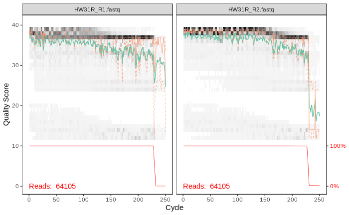

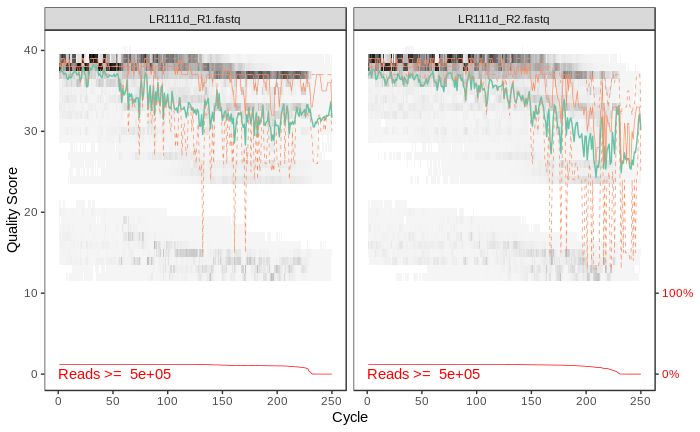

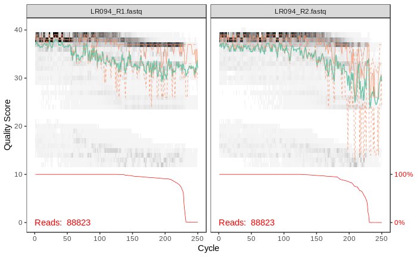

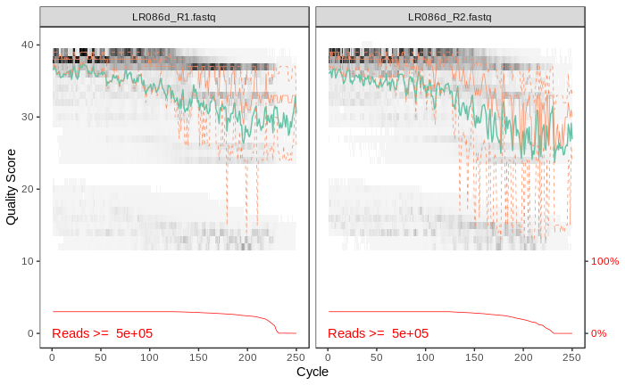

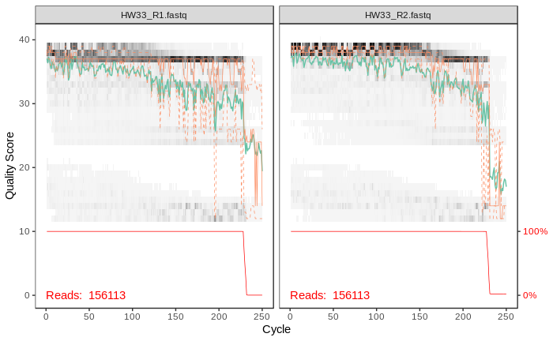

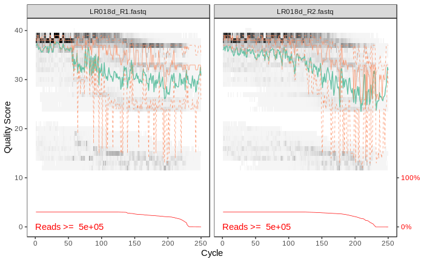

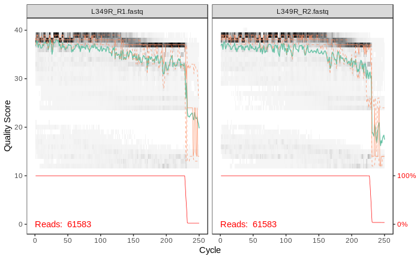

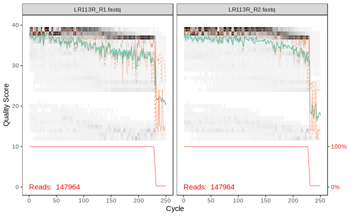

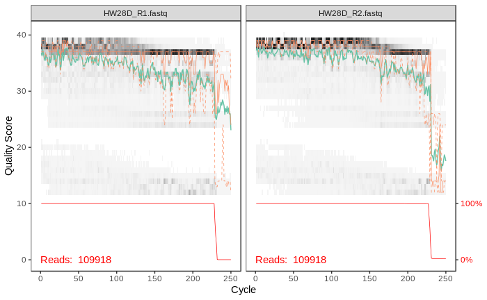

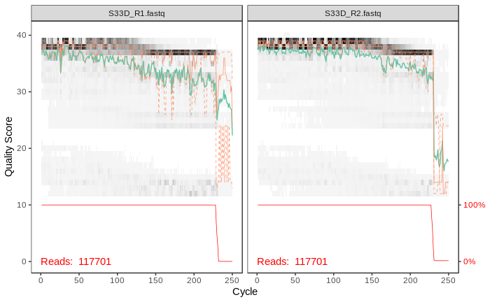

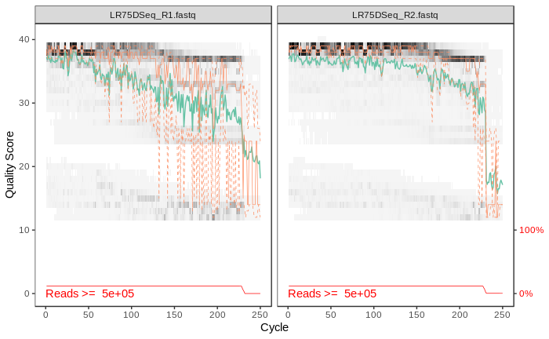

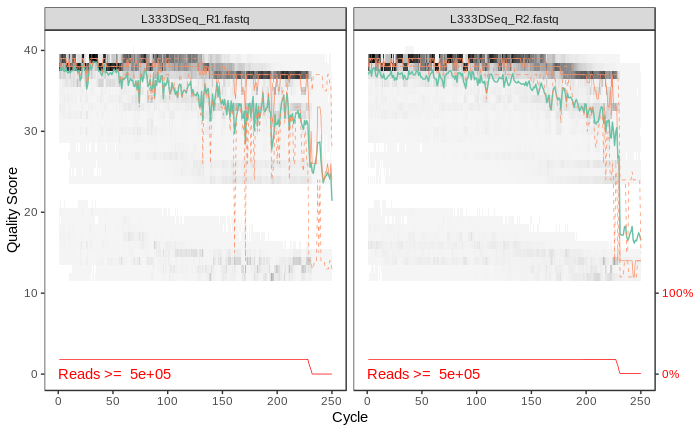

[10 more figures not shown]

```r
qualcheck <- splitdf %>% group_by(splitID) %>% slice(c(1))
# qualityPlot
plyr::d_ply(qualcheck[,c("pathFs","pathRs")], .(qualcheck$splitID), .fun = plotQualityProfile,
                  .print = TRUE)
```

## Prepare for filtering

Add Trimming information, decided based on quality plots c(FWD, REV)

```r
trim <- data.frame(splitID = sort(unique(splitdf$splitID)),
                   TrimF = c(210,225,225,225,225,
                             225,225,225,225,210,
                             210,210,225,225,190,
                             210,225,220,225,225,
                             225,225),
                   TrimR = c(180,180,225,225,225,
                             225,225,225,225,150,
                             150,150,225,225,225,
                             220,225,225,225,225,
                             225,225), stringsAsFactors = F)
splitdf <- left_join(splitdf, trim, by = "splitID")
saveRDS(splitdf, "./Objects/splitdf.rds")
```

Separate data frame content into lists.

```r
pathFs <- list(splitdf$pathFs)
pathRs <- list(splitdf$pathRs)
filtpathFs <- list(splitdf$filtpathFs)
filtpathRs <- list(splitdf$filtpathRs)
trimF <- splitdf$TrimF
trimR <- splitdf$TrimR
```

## Filter

Filter and keep only bases with high enough quality in a looping fashion.

```r
for(i in 1:nrow(splitdf)){
  filterAndTrim(fwd = splitdf$pathFs[i], filt = splitdf$filtpathFs[i], rev = splitdf$pathRs[i],
                filt.rev = splitdf$filtpathRs[i], truncLen = c(splitdf$TrimF[i],splitdf$TrimR[i]),
                maxEE = 2, truncQ = 2, maxN = 0, rm.phix=TRUE, compress=TRUE, verbose=TRUE,
                multithread=TRUE)
}
```

# Learn error rates, infer sequence variants and merge paired-ends

```r
############
# Packages #
############
library("dada2"); packageVersion("dada2")
library("tidyverse")
library("plyr")
```

Some pre-processing. Read-in `splitdf.rds` created in earlier for pooling.

```r
splitdf <- readRDS("./Objects/splitdf.rds")
```

Extract only sample names.

```r
baseFs <- unlist(sapply(splitdf$filtpathFs, basename))
sample.names <- sapply(sapply(baseFs, strsplit, split = "_"), "[[", 1)
```

Splits the paths into separate lists, where each bin represents a `splitID` that contains again a list. In this list, each element is a vector containing the file path to each sample.

```r
Fs <- daply(splitdf[,c("num.splitID","filtpathFs")], .(num.splitID), .fun = list)
Fs <- sapply(Fs, "[[", 2)
Rs <- daply(splitdf[,c("num.splitID","filtpathRs")], .(num.splitID), .fun = list)
Rs <- sapply(Rs, "[[", 2)
#Example:
unique(splitdf$splitID[splitdf$num.splitID == 3])
```

```
[1] "10_Deep"
```

```r
Fs[3]
```

```
$`3`
[1] "/home/bioinf/data/Bioinf.LaRomaine/Raw/withoutPrimers/forward/filtered/L333DSeq_R1.fastq.gz"
[2] "/home/bioinf/data/Bioinf.LaRomaine/Raw/withoutPrimers/forward/filtered/LR72DSeq_R1.fastq.gz"
[3] "/home/bioinf/data/Bioinf.LaRomaine/Raw/withoutPrimers/forward/filtered/SW24DSeq_R1.fastq.gz"
```

```r
Rs[3]
```

```
$`3`
[1] "/home/bioinf/data/Bioinf.LaRomaine/Raw/withoutPrimers/reverse/filtered/L333DSeq_R2.fastq.gz"
[2] "/home/bioinf/data/Bioinf.LaRomaine/Raw/withoutPrimers/reverse/filtered/LR72DSeq_R2.fastq.gz"
[3] "/home/bioinf/data/Bioinf.LaRomaine/Raw/withoutPrimers/reverse/filtered/SW24DSeq_R2.fastq.gz"
```

We will run through the whole process with a loop, where each intermediate product is saved as a R object in the local directory in case memory failure or any other failure interrupts the process. Error rate plots are also saved with the splitID identifier. We have set `MAX_CONSIST = 20` as for some samples convergence was not reached with the default parameter. `nbases = 1e8` is set as advised in the big data tutorial. Pooling is run as ‘pseudo’-pooling, where an ASV table is first created by a sample-by-sample fashion and subsequently, `dada()` runs again with the initial ASV table as reference. This helps to retain singletons by sample, and instead looses only singletons by pool.

```r
for(i in 1:length(Fs)){

  sample.names <- sapply(strsplit(basename(Fs[[i]]),"_"),`[`,1)
  sample.namesR <- sapply(strsplit(basename(Rs[[i]]),"_"),`[`,1)
  if(!identical(sample.names, sample.namesR)) stop("Forward and reverse files do not match.")
  names(Fs[[i]]) <- sample.names
  names(Rs[[i]]) <- sample.namesR

  set.seed(100)

  # Learn forward error rates, save error plot and as R object
  errF <- learnErrors(Fs[[i]], nbases=1e8, multithread=TRUE, MAX_CONSIST = 20)
  saveRDS(errF, file = paste0("./Objects/",i,"_errF.rds"))
  ggsave(paste0("./Figures/",i,"_errF.png"), plot = plotErrors(errF, nominalQ = TRUE),
         units = "cm", width = 40, height = 40)
  # Learn reverse error rates, save error plot and as R object
  errR <- learnErrors(Rs[[i]], nbases=1e8, multithread=TRUE, MAX_CONSIST = 20)
  ggsave(paste0("./Figures/",i,"_errR.png"), plot = plotErrors(errR, nominalQ = TRUE),
         units = "cm", width = 40, height = 40)
  saveRDS(errR, file = paste0("./Objects/",i,"_errR.rds"))

  # Dereplicate
  # Name the derep-class objects by the sample names
  derepFs <- derepFastq(Fs[[i]], verbose=TRUE)
  names(derepFs) <- sample.names
  saveRDS(derepFs, file = paste0("./Objects/",i,"_derepFs.rds"))

  derepRs <- derepFastq(Rs[[i]], verbose=TRUE)
  names(derepRs) <- sample.namesR
  saveRDS(derepRs, file = paste0("./Objects/",i,"_derepRs.rds"))

  # run dada on pooled samples
  poolFs <- dada(derepFs, err=errF, pool='pseudo', multithread = TRUE)
  saveRDS(poolFs, file = paste0("./Objects/",i,"_poolFs.rds"))

  poolRs <- dada(derepRs, err=errR, pool='pseudo', multithread = TRUE)
  saveRDS(poolRs, file = paste0("./Objects/",i,"_poolRs.rds"))
  # merge paired-end reads
  mergers <- mergePairs(poolFs, derepFs, poolRs, derepRs)
  saveRDS(mergers, file = paste0("./Objects/",i,"_mergers.rds"))

  seqtab <- makeSequenceTable(mergers)
  saveRDS(seqtab, file = paste0("./Objects/",i,"_seqtab.rds"))
}
```